# 03-covariance_embedding

Corson N. Areshenkoff

18/03/2022

## Required packages

```r
library(spdm)
library(plyr)
library(ggplot2)
library(RColorBrewer)

# Used by the joint embedding
library(irlba)
library(Matrix)

# The embedding is implemented using the code provided by Wang et al. (2017),
# and published in a repository at https://github.com/shangsiwang/Joint-Embedding.
# As the code is not released with any open license, the script is not
# included here. It can be downloaded from the linked repository and placed
# in the R/ subdirectory.
source('../R/joint_embedding.R')
```

## Data

The embedding is performed on the centered covariance matrices computed in `01-covariance_centering.Rmd`. We will also use the ROI information contained in the cognitive atlas file.

```r
df <- readRDS('../data/output_01-covariance_centering.rds')
atlas <- read.csv('../data/atlas_cognitive_network.csv', header = T)
head(atlas)
```

```
##           Network Region Hemisphere      x      y     z
## 1 DorsalAttention cortex       left -26.60 -70.72 36.86
## 2 DorsalAttention cortex      right  21.90 -64.74 48.12
## 3 DorsalAttention cortex       left -52.44 -63.14  5.29
## 4 DorsalAttention cortex      right   9.61 -61.50 60.88
## 5 DorsalAttention cortex       left -42.26 -60.12 -8.85
## 6 DorsalAttention cortex      right  46.09 -58.93  3.93
```

## Embedding

Each tangent vector saved in `01-covariance_centering.Rmd` encodes the difference in functional connectivity relative to the grand mean covariance matrix, so that e.g. a positive value in entry (i,j) indicates a greater than average covariance between region i and j. The embedding thus captures the main patterns of change in connectivity around the average.

```r
embedding  <- multidembed(df$TanVec, d = 2)
components <- embedding$h
scores     <- embedding$lambda
```

The components themselves give an embedding of the ROIs into two dimensions, where regions which are located nearby tend to vary from the average in similar ways, and regions located closer to the origin tend not to vary much from the average at all.

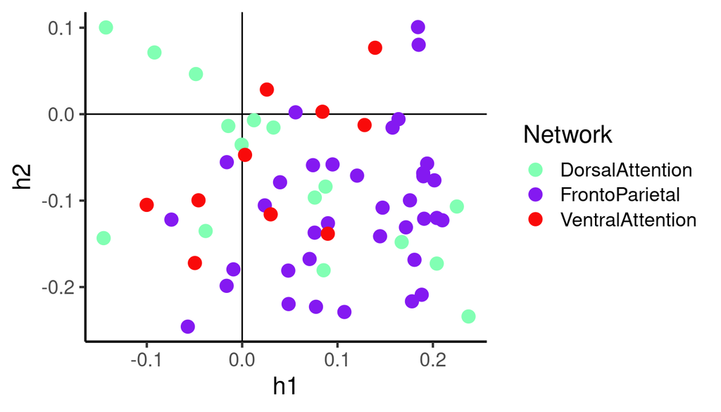

```r
pf.comps <- data.frame(Network = atlas$Network,
                       h1 = components[,1], h2 = components[,2])
ggplot(pf.comps, aes(x = h1, y = h2, color = Network)) +
    theme_classic(base_size = 17) +
    geom_vline(xintercept = 0) +
    geom_hline(yintercept = 0) +
    scale_color_manual(values = c('#81ffb3', '#8419f1', '#f90a0a')) +
    geom_point(size = 4)
```

These components form a basis for the space of centered tangent vectors, so that each tagent vector V is approximated as an additive combination V = s<sub>1</sub>H<sub>1</sub> + s<sub>2</sub>H<sub>2</sub>, where s<sub>1</sub> is the score on component 1, and H<sub>1</sub> is the outer product h<sub>1</sub>’h<sub>1</sub>. These matrices H1 and H2 may be more interpretable than the component plot above, as they are direct visualizations of the change in covariance associated with each component.

It is useful to compare these component with the grand mean covariance, so we compute that here and order the ROIs using hierarchical clustering. For each of comparison, we will use this same ordering for the components.

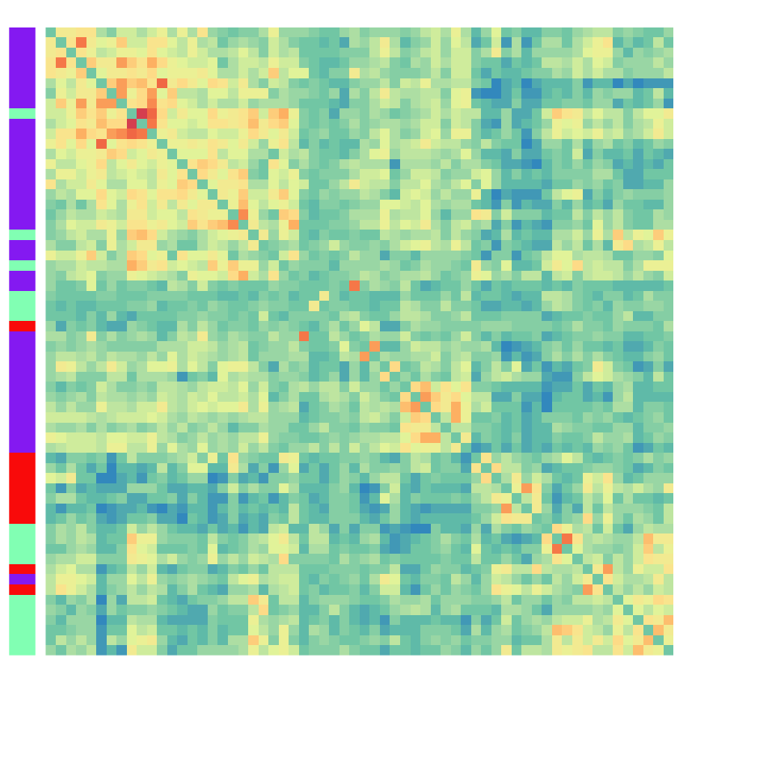

```r
grand.mean <- spd.mean(df$Cov)
grand.mean <- grand.mean - diag(diag(grand.mean))
ord <- hclust(dist(grand.mean))$order

network.colors <- mapvalues(atlas$Network,
                            from = c('DorsalAttention', 'FrontoParietal',
                                     'VentralAttention'),
                            to = c('#81ffb3', '#8419f1', '#f90a0a'))
colormap <- rev(colorRampPalette(brewer.pal(8, "Spectral"))(25))

heatmap(grand.mean[ord,ord],
        symm = T, Rowv = NA, labRow = NA, labCol = NA,
        RowSideColors = network.colors[ord],
        col = colormap)
```

Note the large community comprising regions in the frontoparietal network (top left). The first component in particular (H1; below) appears to prominently encode a relative increase or decrease in the covariance within this community, so that higher scores are associated with greater than average functional connectivity within this subset of frontoparietal regions.

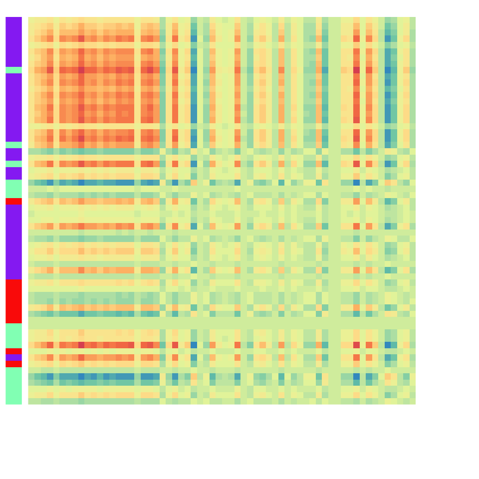

```r
H1 <- components[,1] %o% components[,1]
heatmap(H1[ord,ord],
        symm = T, Rowv = NA, labRow = NA, labCol = NA,
        RowSideColors = network.colors[ord],
        col = colormap)
```

This component appears to strongly distinguish between resting state and task scans, with task scans showing positive scores, and thus greater functional connectivity within this cluster of frontoparietal regions.

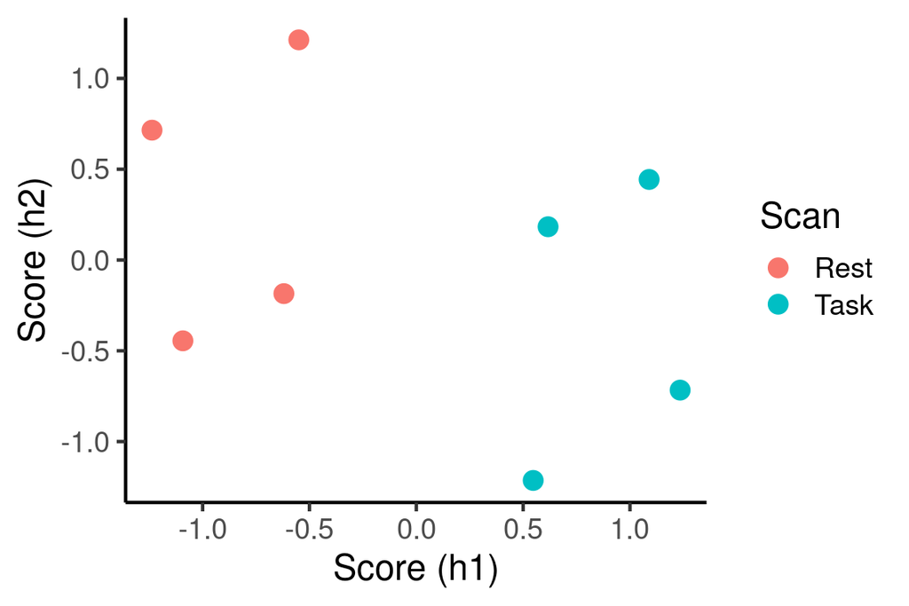

```r
pf.scores <- data.frame(Subject = df$Subject, Scan = df$Scan,
                        h1 = scores[,1], h2 = scores[,2])
ggplot(pf.scores, aes(x = h1, y = h2, color = Scan)) +
    theme_classic(base_size = 17) +
    xlab('Score (h1)') + ylab('Score (h2)') +
    geom_point(size = 4)
```